# Tweets zu den Landtagswahlen in Bayern

```r
load(file="ltw18by_tweets.Rda")
```

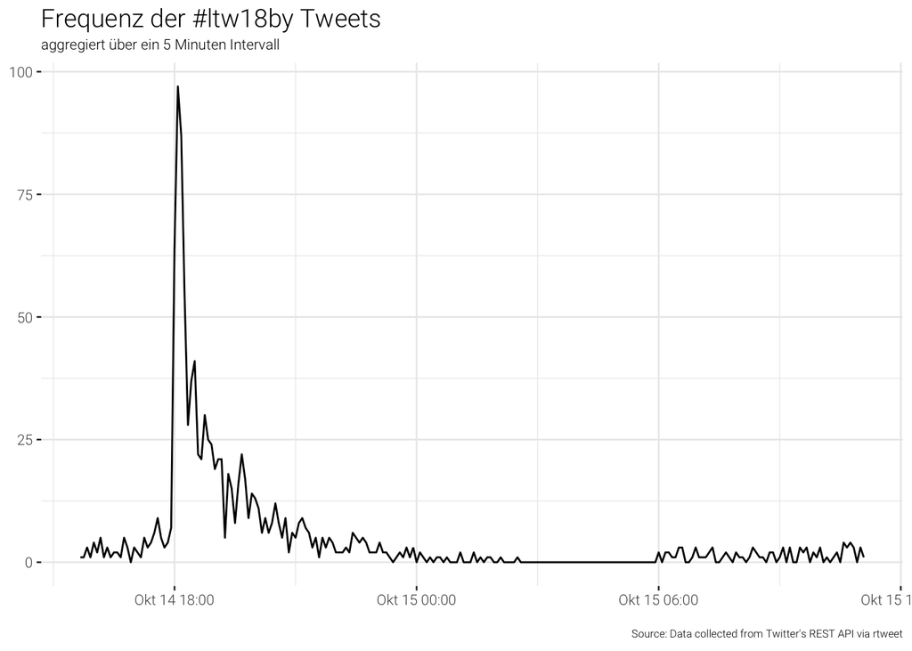

```r
rt %>%
  mutate(created_at = created_at + hours(2)) %>%
  filter(created_at > as.POSIXct("2018-10-14 17:00:00")) %>%
  ts_plot("5 minutes") +
  ggplot2::labs(
    x = NULL, y = NULL,
    title = "Frequenz der #ltw18by Tweets",
    subtitle = "aggregiert über ein 5 Minuten Intervall",
    caption = "\nSource: Data collected from Twitter's REST API via rtweet"
  )
```

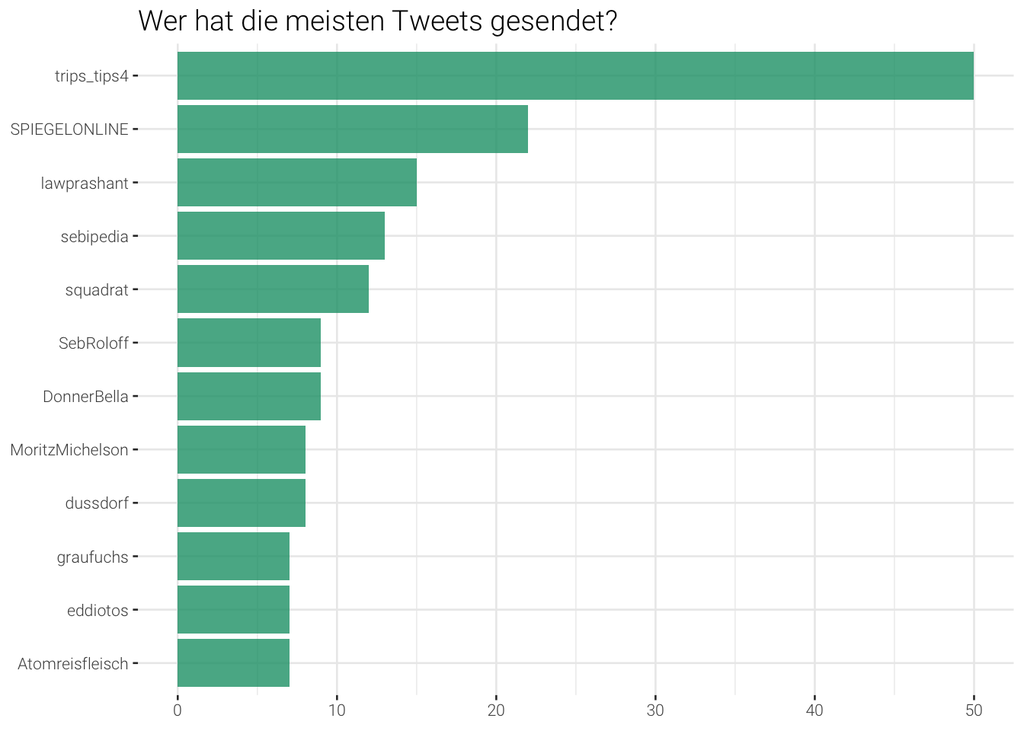

```r
rt %>%
  count(screen_name, sort=TRUE) %>%
  top_n(10) %>%
  ggplot(aes(reorder(screen_name, n),n)) +
  geom_col(fill = col[1], alpha = 0.8) +
  coord_flip() +
  labs(x = NULL, y = NULL, title = "Wer hat die meisten Tweets gesendet?")
```

## Welche Tweets wurden am häufigsten geteilt?

```r
rt %>%
  select(screen_name, text, retweet_count) %>%
  arrange(desc(retweet_count)) %>%
  top_n(15, retweet_count) %>%
  htmlTable::htmlTable(align = "l")
```

screen_name

text

retweet_count

1

Alice_Weidel

Ich gratuliere der @AfD_Bayern zu diesem riesigen Erfolg! #Bayern hat gewählt und der Politik der CSU & damit auch der Kanzlerin eine mehr als deutliche Absage erteilt. Die #AfD ist mit 11 % erstmals im Bayerischen Landtag vertreten. #LtwBayern #ltw18by ➡️https://t.co/OSmeq12blE https://t.co/YNb7OmO7ue

549

2

igorpianist

Wow. Zieht Euch das mal rein. Irre. Stärkste Kraft in Bayerns Städten. @Die_Gruenen #ltw18by https://t.co/v3dAeaLaXk

297

3

kattascha

Ich bin optimistisch, dass die #SPD ihre Einstellung zur 5% Hürde in den nächsten Jahren überdenken wird. #LTWby2018 #ltw18by #ltwbayern2018

291

4

Joerg_Meuthen

Glückwunsch an die @AfD_Bayern! Wir sind Wahlsieger! Deutlich zweistellig und da geht noch was! #CSU und #SPD böse abgestraft für desolate Politik. #AfD #Bayern #ltw18by

276

5

sven_giegold

Das muss man sich nochmal klar machen: Diesen historischen Wahlsieg haben die @Gruene_Bayern mit dem Motto “Herz statt Hetze” eingefahren. Bayern ist weltoffen und solidarisch! Ein so wichtiges Signal in dieser Zeit! #LTWby2018 #ltw18by #ltwbayern2018 https://t.co/04b3WD6WIJ

131

6

SPIEGELONLINE

In München, Nürnberg, Augsburg, Regensburg, Ingolstadt, Würzburg, Fürth und Erlangen - Bayerns Städten mit mehr als 100.000 Einwohnern - wählten 30 Prozent die Grünen. #LtwBayern #ltw18by https://t.co/Mz7aPoVVat

119

7

Leif_Erik_Holm

Erste Prognose zur Bayern-Wahl: #AfD zweistellig drin, Erdrutschklatschen für #CSU und #SPD. Die Erosion der ehemaligen Volksparteien beschleunigt sich. Das ist das Resultat, wenn man keine Ahnung von den Nöten der Bürger hat. #WindofChange #ltw18by #LtwBayern18 https://t.co/8PFnhr0dej

119

8

MalteKaufmann

HERZLICHEN GLÜCKWUNSCH! #AfD im #Landtag von #Bayern 👍🇩🇪#LtwBayern #LTWBayern2018 #ltwby2018 #ltwby #ltw18by

114

9

publizistikon

Wie “demokratisch” die Grünen von Duracell-Häschen Katharina Schulze sind, lässt sich auch an den Gratulanten ablesen… #ltw18by #LtwBayern #Extremismus https://t.co/8stfi6F2nI

106

10

astefanowitsch

#RealityCheck Das Ergebnis der Landtagswahl in Bayern nach Lagern (Rechts: CSU, FW, AfD, FDP, BP; Mitte: GRÜNE, SPD, ÖDP; Links: LINKE) #ltw18by #LtwBayern https://t.co/GM0wjjsWdl

92

11

sven_giegold

Europa strahlt heute Grün! Auch in #Luxemburg heute ein historischer Wahlerfolg für die Grüne Partei: 14.8% ist das beste Ergebnis seit Parteigründung. Herzlichen Glückwunsch, @deigreng! #ltwby2018 #ltw18by #Bayernwahl #Walen2018 #gréng2018 https://t.co/DHM6bBeMEq

85

12

anettselle

In Bayerns Städten sind die Grünen die stärkste Partei. #ltw18by #ltwby #ltwby2018 Gesehen bei @igorpianist https://t.co/hO3xJ76tlb

72

13

DJanecek

Die @AfD_Bayern hat übrigens im Vergleich zur Bundestagswahl 2017 deutlich an Stimmen verloren. #AfD #ltw18by

66

14

SPIEGELONLINE

So sieht es in der zweiten Hochrechnung aus. Alle Ergebnisse aus #Bayern findet Ihr hier: https://t.co/Sd2MRUwE9Y #ltwby18 #ltw18by #ltwby2018 #LtwBayern https://t.co/YemtyOxGan

58

15

CasMudde

Key issues in #BavarianElection were:

- school- and education policy (52%)
- creation of affordable housing (51%)
- environmental and climate policy (49%) … … …
- immigration policy (33%)

#ltwby2018 #LtwBayern18 #ltw18by https://t.co/OWBoIJvKCo

58

## Welche Tweets wurden am häufigsten favorisiert?

```r
rt %>%
  select(screen_name, text, favorite_count) %>%
  arrange(desc(favorite_count)) %>%
  top_n(15, favorite_count) %>%
  htmlTable::htmlTable(align = "l")
```

screen_name

text

favorite_count

1

Alice_Weidel

Ich gratuliere der @AfD_Bayern zu diesem riesigen Erfolg! #Bayern hat gewählt und der Politik der CSU & damit auch der Kanzlerin eine mehr als deutliche Absage erteilt. Die #AfD ist mit 11 % erstmals im Bayerischen Landtag vertreten. #LtwBayern #ltw18by ➡️https://t.co/OSmeq12blE https://t.co/YNb7OmO7ue

1853

2

kattascha

Ich bin optimistisch, dass die #SPD ihre Einstellung zur 5% Hürde in den nächsten Jahren überdenken wird. #LTWby2018 #ltw18by #ltwbayern2018

1312

3

igorpianist

Wow. Zieht Euch das mal rein. Irre. Stärkste Kraft in Bayerns Städten. @Die_Gruenen #ltw18by https://t.co/v3dAeaLaXk

1145

4

Joerg_Meuthen

Glückwunsch an die @AfD_Bayern! Wir sind Wahlsieger! Deutlich zweistellig und da geht noch was! #CSU und #SPD böse abgestraft für desolate Politik. #AfD #Bayern #ltw18by

1083

5

sven_giegold

Das muss man sich nochmal klar machen: Diesen historischen Wahlsieg haben die @Gruene_Bayern mit dem Motto “Herz statt Hetze” eingefahren. Bayern ist weltoffen und solidarisch! Ein so wichtiges Signal in dieser Zeit! #LTWby2018 #ltw18by #ltwbayern2018 https://t.co/04b3WD6WIJ

672

6

Leif_Erik_Holm

Erste Prognose zur Bayern-Wahl: #AfD zweistellig drin, Erdrutschklatschen für #CSU und #SPD. Die Erosion der ehemaligen Volksparteien beschleunigt sich. Das ist das Resultat, wenn man keine Ahnung von den Nöten der Bürger hat. #WindofChange #ltw18by #LtwBayern18 https://t.co/8PFnhr0dej

459

7

MalteKaufmann

HERZLICHEN GLÜCKWUNSCH! #AfD im #Landtag von #Bayern 👍🇩🇪#LtwBayern #LTWBayern2018 #ltwby2018 #ltwby #ltw18by

402

8

SPIEGELONLINE

In München, Nürnberg, Augsburg, Regensburg, Ingolstadt, Würzburg, Fürth und Erlangen - Bayerns Städten mit mehr als 100.000 Einwohnern - wählten 30 Prozent die Grünen. #LtwBayern #ltw18by https://t.co/Mz7aPoVVat

389

9

fdp

5% - Vielen Dank an alle Wähler, Wahlkämpfer und Unterstützer #FrischesBayer #LtwBayern18 #ltw18 #ltw18by

352

10

DJanecek

Die @AfD_Bayern hat übrigens im Vergleich zur Bundestagswahl 2017 deutlich an Stimmen verloren. #AfD #ltw18by

290

11

anettselle

In Bayerns Städten sind die Grünen die stärkste Partei. #ltw18by #ltwby #ltwby2018 Gesehen bei @igorpianist https://t.co/hO3xJ76tlb

287

12

sven_giegold

Europa strahlt heute Grün! Auch in #Luxemburg heute ein historischer Wahlerfolg für die Grüne Partei: 14.8% ist das beste Ergebnis seit Parteigründung. Herzlichen Glückwunsch, @deigreng! #ltwby2018 #ltw18by #Bayernwahl #Walen2018 #gréng2018 https://t.co/DHM6bBeMEq

269

13

danieldrepper

Wir machen heute bei @BuzzFeedNewsDE übrigens nichts zur #Bayernwahl, weil

- es Hochrechnungen auf allen anderen Seiten gibt
- ich nicht den Eindruck habe, es mangele an Meinung und Analyse
- wir unsere knappen Ressourcen für eigene Recherchen nutzen

-> Empfehle @sz

#ltw18by

265

14

MiKellner

Was für ein Vertrauen in Grün. Ganz herzliche Glückwünsche an @Gruene_Bayern - Respekt und Dankbarkeit vor dem Vertrauen der vielen Wählerinnen und Wähler. Die #CSU dachte, sie ist Bayern. Nur Bayern dachte das nicht mehr. #ltw18by

261

15

fdp

5,1% in Bayern! Wir fiebern mit der @fdpbay - Hut ab an @realMartinHagen & alle Wähler, Wahlkämpfer und Unterstützer für diesen starken Wahlkampf. #LTWBayern18 #ltw18 #ltw18by Eindrücke vom Wahlabend im HDGH: https://t.co/ah0TIen6BM

256

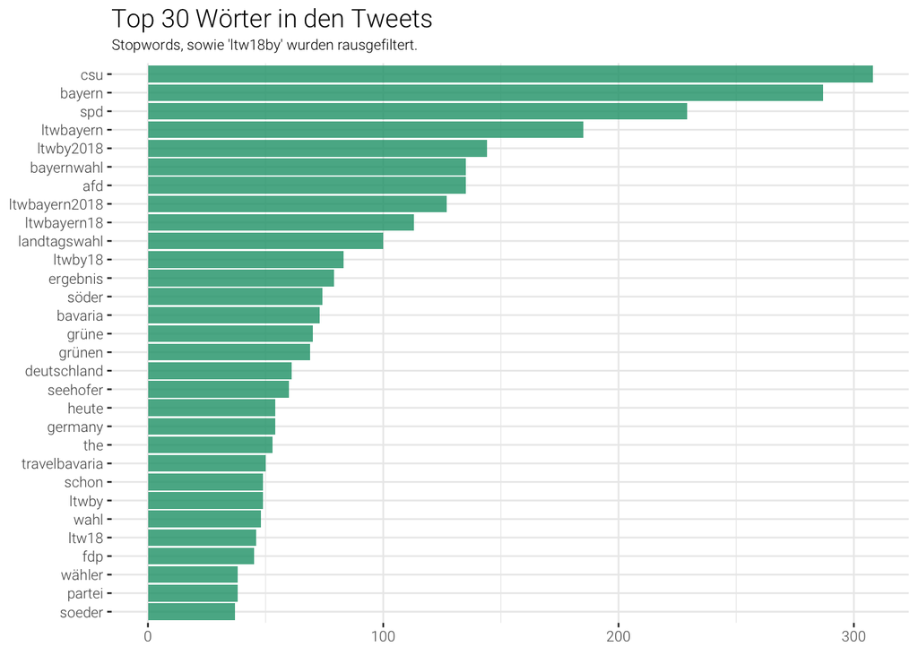

```r
library(tidytext)
# define stopwords
stop_words <- stopwords::stopwords("de", source = "snowball")
stop_words <- c(stop_words, "https","t.co","mal","mehr","ltw18by","dass")

tokenized <- rt %>%
  select(status_id, screen_name, created_at, text) %>%
  unnest_tokens("words", text) %>%
  filter(!words %in% stop_words)

tokenized %>%
  count(words, sort = T) %>%
  top_n(30) %>%
  ggplot(aes(reorder(words, n),n)) +
  geom_col(fill = col[1], alpha=0.8) +
  coord_flip() +
  labs(x = NULL, y = NULL, title = "Top 30 Wörter in den Tweets",
       subtitle = "Stopwords, sowie 'ltw18by' wurden rausgefiltert.")
```

[Link zum Notebook](https://github.com/franziloew/Ltw19by/blob/master/ltw18by.Rmd)